# R21 Resting-State Network Coupling Report

Final N=27 report for coupling among the original 10 Smith09 networks. It presents only DMN coupling with ECN, left FPN, and right FPN. Full correlations are ordinary Pearson correlations; partial correlations control the other eight Smith09 timecourses through the precision matrix.

Condition inference is restricted to the same three nonredundant contrasts used in the primary report. The secondary DMN x ECN physio-physio interaction (PPI) analysis uses the original 10-map model. Unrelated-network analyses are intentionally excluded.

```python
from pathlib import Path
from io import BytesIO
import json

import matplotlib.pyplot as plt
import nibabel as nib
from nilearn import datasets, image, plotting
import numpy as np
import pandas as pd
from scipy import ndimage
from IPython.display import display, Markdown, Image as IPyImage


def find_project_root(start=Path.cwd()):
    for candidate in (start, *start.parents):
        if (candidate / 'code' / 'dual_regression').is_file():
            return candidate
    raise FileNotFoundError('Start Jupyter from the r21-rest repository or a subdirectory.')


PROJECT_ROOT = find_project_root()
CONDITIONS = ['sham', 'rtpj', 'vlpfc', 'both']
CONDITION_LABELS = ['Sham', 'RTPJ', 'VLPFC', 'BOTH']
CONDITION_COLORS = ['#8A8F98', '#2878B5', '#D95F59', '#3A9D6F']
CORE_CONTRASTS = [
    'mean-stimulation-minus-sham',
    'both-minus-mean-rtpj-vlpfc',
    'rtpj-minus-vlpfc',
]
CONTRAST_LABELS = {
    'mean-stimulation-minus-sham': 'mean(stimulation) - Sham',
    'both-minus-mean-rtpj-vlpfc': 'BOTH - mean(RTPJ, VLPFC)',
    'rtpj-minus-vlpfc': 'RTPJ - VLPFC',
}
CONTRAST_TERMS = {
    'mean-stimulation-minus-sham': ('mean(stimulation)', 'Sham'),
    'both-minus-mean-rtpj-vlpfc': ('BOTH', 'mean(RTPJ, VLPFC)'),
    'rtpj-minus-vlpfc': ('RTPJ', 'VLPFC'),
}
TAIL_CORRP_THRESHOLD = 0.975

plt.rcParams.update({
    'figure.dpi': 120,
    'savefig.dpi': 160,
    'axes.spines.top': False,
    'axes.spines.right': False,
    'font.size': 10,
})


def display_figure(fig, dpi=150):
    buffer = BytesIO()
    fig.savefig(buffer, format='png', dpi=dpi, bbox_inches='tight', facecolor='white')
    plt.close(fig)
    display(IPyImage(data=buffer.getvalue()))


def project_path(value):
    path = Path(str(value))
    return path if path.is_absolute() else PROJECT_ROOT / path


def signed_effect(contrast, direction):
    first, second = CONTRAST_TERMS[contrast]
    if str(direction).lower() == 'negative':
        first, second = second, first
    return f'{first} > {second}'


print('Project root:', PROJECT_ROOT)
```

```
Project root: /Users/tug87422/github/r21-rest
```

```python
NETWORK_DIR = PROJECT_ROOT / 'derivatives' / 'fsl' / 'network_correlation_summary'
RUN_PATH = NETWORK_DIR / 'task-rest_analysis-smith09_denoised_network-correlation_run-values.tsv'
PPI_DIR = PROJECT_ROOT / 'derivatives' / 'fsl' / 'ppi_randomise_summary'
PPI_PATH = PPI_DIR / 'task-rest_ppi-dmn-ecn_randomise_peak_summary.tsv'

run_values = pd.read_csv(RUN_PATH, sep='\t')
run_values['r'] = pd.to_numeric(run_values['r'], errors='raise')
run_values['fisher_z'] = pd.to_numeric(run_values['fisher_z'], errors='raise')
TARGET_PAIRS = ['dmn__ecn', 'dmn__left-fpn', 'dmn__right-fpn']
PAIR_LABELS = {
    'dmn__ecn': 'DMN - ECN',
    'dmn__left-fpn': 'DMN - left FPN',
    'dmn__right-fpn': 'DMN - right FPN',
}
focused = run_values[run_values['network_pair'].isin(TARGET_PAIRS)].copy()
assert focused['participant'].nunique() == 27
assert focused['condition'].nunique() == 4
assert focused['network_pair'].nunique() == 3
assert focused['correlation_type'].nunique() == 2
print('Focused run-level correlations:', len(focused), '| participants:', focused.participant.nunique())
```

```
Focused run-level correlations: 648 | participants: 27
```

DMN coupling by condition

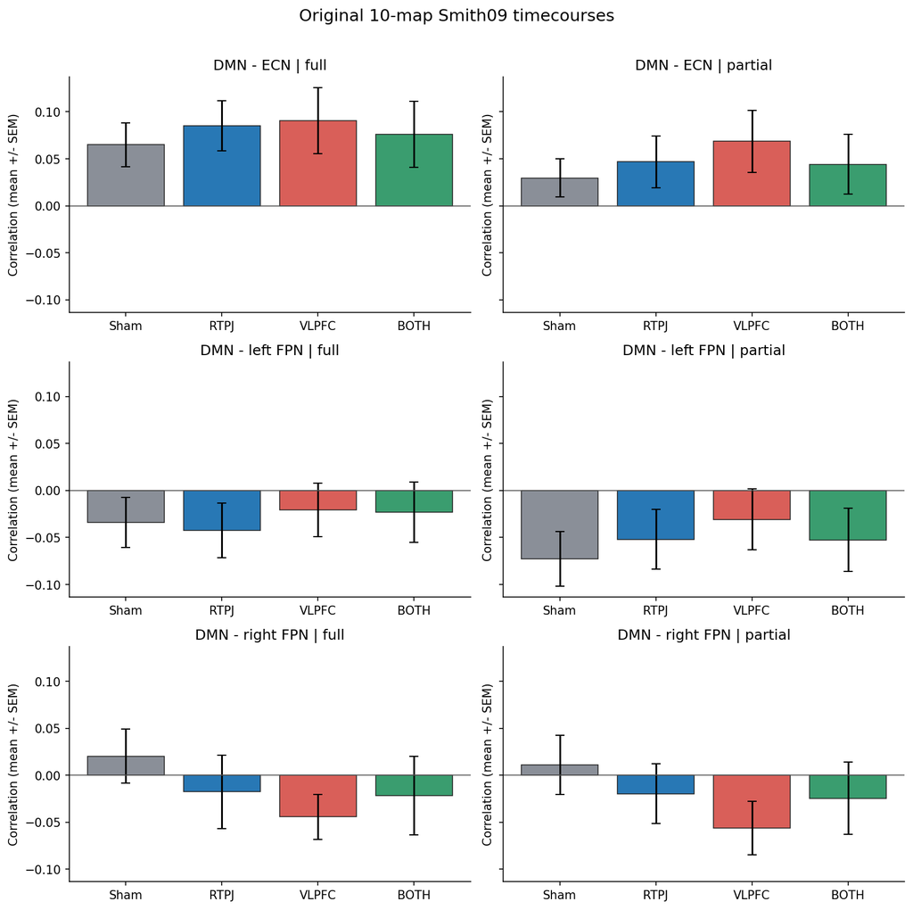

```python
display(Markdown('## DMN coupling by condition'))
fig, axes = plt.subplots(3, 2, figsize=(10.8, 10.5), sharey=True)
for row_index, pair in enumerate(TARGET_PAIRS):
    for column_index, corr_type in enumerate(['full', 'partial']):
        ax = axes[row_index, column_index]
        subset = focused[focused['network_pair'].eq(pair) & focused['correlation_type'].eq(corr_type)]
        grouped = subset.groupby('condition')['r'].agg(['mean', 'sem', 'count']).reindex(CONDITIONS)
        positions = np.arange(4)
        ax.bar(positions, grouped['mean'], yerr=grouped['sem'], capsize=4,
               color=CONDITION_COLORS, edgecolor='#222222', linewidth=.75)
        ax.axhline(0, color='#555555', linewidth=.8)
        ax.set_xticks(positions, CONDITION_LABELS)
        ax.set_ylabel('Correlation (mean +/- SEM)')
        ax.set_title(f'{PAIR_LABELS[pair]} | {corr_type}')
fig.suptitle('Original 10-map Smith09 timecourses', fontsize=14, y=1.01)
fig.tight_layout()
display_figure(fig)
```

```python
CONTRAST_WEIGHTS = {
    'mean-stimulation-minus-sham': {'sham': -1.0, 'rtpj': 1/3, 'vlpfc': 1/3, 'both': 1/3},
    'both-minus-mean-rtpj-vlpfc': {'rtpj': -0.5, 'vlpfc': -0.5, 'both': 1.0},
    'rtpj-minus-vlpfc': {'rtpj': 1.0, 'vlpfc': -1.0},
}


def signflip_p(values, n_perm=100000, seed=20260806):
    values = np.asarray(values, dtype=float)
    observed = float(values.mean())
    rng = np.random.default_rng(seed)
    signs = rng.choice((-1.0, 1.0), size=(n_perm, len(values)))
    permutation_means = signs @ values / len(values)
    return float((np.count_nonzero(np.abs(permutation_means) >= abs(observed)) + 1) / (n_perm + 1))


contrast_records = []
seed_index = 0
for pair in TARGET_PAIRS:
    for corr_type in ['full', 'partial']:
        subset = focused[focused['network_pair'].eq(pair) & focused['correlation_type'].eq(corr_type)]
        pivot = subset.pivot(index='participant', columns='condition', values='fisher_z').reindex(columns=CONDITIONS)
        assert pivot.shape == (27, 4) and not pivot.isna().any().any()
        for contrast in CORE_CONTRASTS:
            weights = CONTRAST_WEIGHTS[contrast]
            delta = sum(pivot[condition] * weight for condition, weight in weights.items())
            mean = float(delta.mean())
            sem = float(delta.std(ddof=1) / np.sqrt(len(delta)))
            contrast_records.append({
                'Pair': PAIR_LABELS[pair],
                'Correlation': corr_type,
                'Contrast': CONTRAST_LABELS[contrast],
                'N': len(delta),
                'Mean delta Fisher z': mean,
                'SEM': sem,
                'Two-sided sign-flip p': signflip_p(delta, seed=20260806 + seed_index),
            })
            seed_index += 1

contrast_audit = pd.DataFrame(contrast_records)
display(Markdown('## Complete three-contrast coupling audit'))
display(contrast_audit.style.format({
    'Mean delta Fisher z': '{:+.4f}', 'SEM': '{:.4f}', 'Two-sided sign-flip p': '{:.4f}',
}).hide(axis='index'))
print('Nominal p<.05 coupling contrasts:', int((contrast_audit['Two-sided sign-flip p'] < .05).sum()))
```

Complete three-contrast coupling audit

| Pair | Correlation | Contrast | N | Mean delta Fisher z | SEM | Two-sided sign-flip p |
| --- | --- | --- | --- | --- | --- | --- |
| DMN - ECN | full | mean(stimulation) - Sham | 27 | +0.0208 | 0.0230 | 0.3719 |
| DMN - ECN | full | BOTH - mean(RTPJ, VLPFC) | 27 | -0.0126 | 0.0277 | 0.6540 |
| DMN - ECN | full | RTPJ - VLPFC | 27 | -0.0060 | 0.0303 | 0.8457 |
| DMN - ECN | partial | mean(stimulation) - Sham | 27 | +0.0246 | 0.0263 | 0.3576 |
| DMN - ECN | partial | BOTH - mean(RTPJ, VLPFC) | 27 | -0.0139 | 0.0235 | 0.5579 |
| DMN - ECN | partial | RTPJ - VLPFC | 27 | -0.0225 | 0.0277 | 0.4388 |
| DMN - left FPN | full | mean(stimulation) - Sham | 27 | +0.0051 | 0.0270 | 0.8471 |
| DMN - left FPN | full | BOTH - mean(RTPJ, VLPFC) | 27 | +0.0088 | 0.0310 | 0.7765 |
| DMN - left FPN | full | RTPJ - VLPFC | 27 | -0.0221 | 0.0263 | 0.4049 |
| DMN - left FPN | partial | mean(stimulation) - Sham | 27 | +0.0288 | 0.0299 | 0.3478 |
| DMN - left FPN | partial | BOTH - mean(RTPJ, VLPFC) | 27 | -0.0132 | 0.0320 | 0.6829 |
| DMN - left FPN | partial | RTPJ - VLPFC | 27 | -0.0216 | 0.0273 | 0.4388 |
| DMN - right FPN | full | mean(stimulation) - Sham | 27 | -0.0500 | 0.0257 | 0.0617 |
| DMN - right FPN | full | BOTH - mean(RTPJ, VLPFC) | 27 | +0.0091 | 0.0353 | 0.7982 |
| DMN - right FPN | full | RTPJ - VLPFC | 27 | +0.0252 | 0.0423 | 0.5551 |
| DMN - right FPN | partial | mean(stimulation) - Sham | 27 | -0.0465 | 0.0277 | 0.1053 |
| DMN - right FPN | partial | BOTH - mean(RTPJ, VLPFC) | 27 | +0.0132 | 0.0355 | 0.7139 |
| DMN - right FPN | partial | RTPJ - VLPFC | 27 | +0.0379 | 0.0379 | 0.3252 |

```
Nominal p<.05 coupling contrasts: 0
```

DMN x ECN PPI contrast audit

| Contrast | Strongest direction | Best one-sided FWE p | Conservative two-sided p | Result |
| --- | --- | --- | --- | --- |
| mean(stimulation) - Sham | mean(stimulation) > Sham | 0.9398 | 1.0000 | null |
| BOTH - mean(RTPJ, VLPFC) | BOTH > mean(RTPJ, VLPFC) | 0.0248 | 0.0496 | significant |
| RTPJ - VLPFC | VLPFC > RTPJ | 0.0184 | 0.0368 | significant |

DMN x ECN: BOTH > mean(RTPJ, VLPFC)

Peak one-sided FWE-corrected p = 0.0248; conservative two-sided p = **0.0496**. The `1-p > .975` display contains 11 voxels in 1 connected cluster(s).

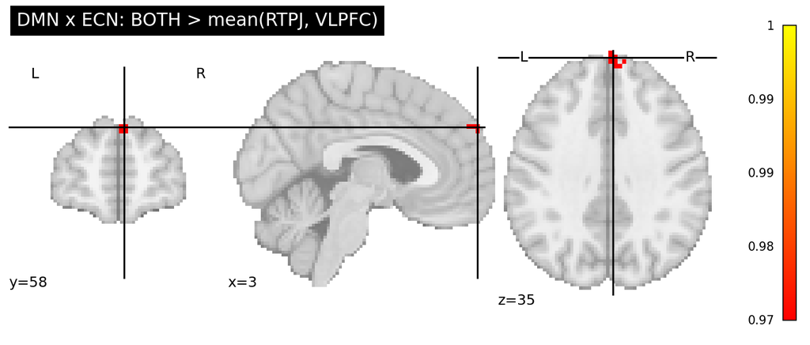

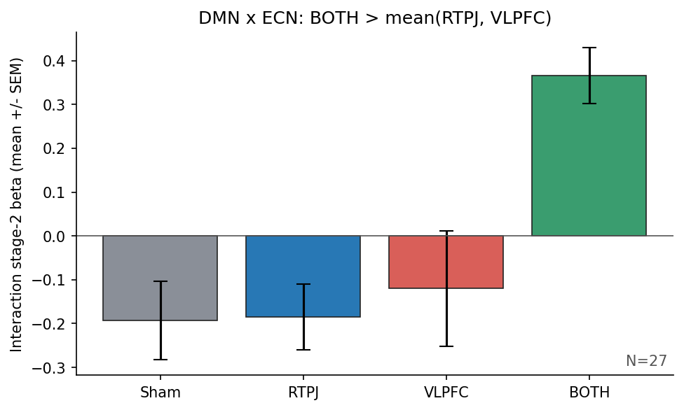

DMN x ECN: VLPFC > RTPJ

Peak one-sided FWE-corrected p = 0.0184; conservative two-sided p = **0.0368**. The `1-p > .975` display contains 13 voxels in 1 connected cluster(s).

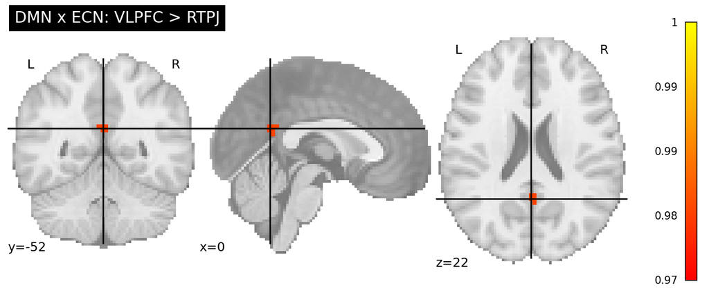

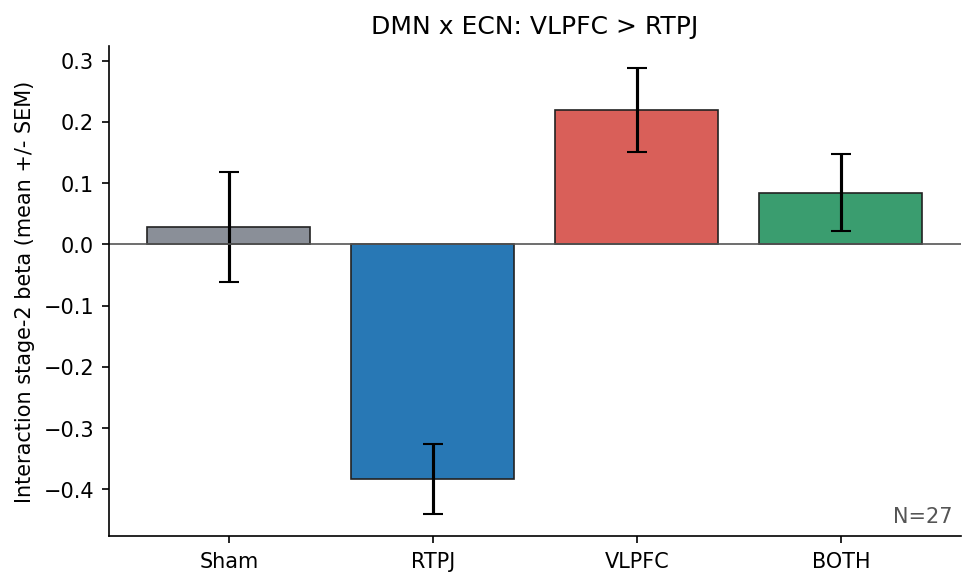

```python
ppi = pd.read_csv(PPI_PATH, sep='\t', dtype=str).fillna('')
ppi = ppi[
    ppi['condition_contrast'].isin(CORE_CONTRASTS)
    & ppi['inference'].eq('cluster-extent')
    & ppi['status'].eq('ok')
].copy()
assert set(ppi['condition_contrast']) == set(CORE_CONTRASTS), (
    'The original 10-map PPI summary must contain all three final contrasts'
)
ppi['peak_corrp'] = pd.to_numeric(ppi['peak_corrp'], errors='raise')
ppi['one_sided_p'] = 1.0 - ppi['peak_corrp']

ppi_audit = []
ppi_winners = []
for contrast in CORE_CONTRASTS:
    subset = ppi[ppi['condition_contrast'].eq(contrast)]
    if subset.empty:
        ppi_audit.append({
            'Contrast': CONTRAST_LABELS[contrast],
            'Strongest direction': 'missing from PPI summary',
            'Best one-sided FWE p': np.nan,
            'Conservative two-sided p': np.nan,
            'Result': 'missing',
        })
        continue
    assert set(subset['direction']) == {'positive', 'negative'}
    winner = subset.sort_values('one_sided_p').iloc[0]
    two_sided_p = min(1.0, 2.0 * float(winner['one_sided_p']))
    ppi_audit.append({
        'Contrast': CONTRAST_LABELS[contrast],
        'Strongest direction': signed_effect(contrast, winner['direction']),
        'Best one-sided FWE p': float(winner['one_sided_p']),
        'Conservative two-sided p': two_sided_p,
        'Result': 'significant' if two_sided_p < .05 else 'null',
    })
    if two_sided_p < .05:
        ppi_winners.append((winner, two_sided_p))

display(Markdown('## DMN x ECN PPI contrast audit'))
display(pd.DataFrame(ppi_audit).style.format({
    'Best one-sided FWE p': '{:.4f}', 'Conservative two-sided p': '{:.4f}',
}).hide(axis='index'))

MNI_TEMPLATE = datasets.load_mni152_template(resolution=2)
CACHE_DIR = PPI_DIR / '.notebook_cache_final'
CACHE_DIR.mkdir(exist_ok=True)

for row, two_sided_p in ppi_winners:
    title = f"DMN x ECN: {signed_effect(row['condition_contrast'], row['direction'])}"
    copied = project_path(row['copied_image'])
    values_path = project_path(row['roi_values_tsv'])
    corrp_img = image.load_img(copied)
    corrp_data = np.asarray(corrp_img.dataobj)
    roi = np.isfinite(corrp_data) & (corrp_data > TAIL_CORRP_THRESHOLD)
    _labels, n_clusters = ndimage.label(roi, structure=np.ones((3, 3, 3), dtype=np.uint8))
    thresholded = image.new_img_like(corrp_img, np.where(roi, corrp_data, 0.0), copy_header=True)
    overlay = CACHE_DIR / copied.name.replace('_stat-corrp_statmap.nii.gz', '_desc-twoSidedThresholded_statmap.nii.gz')
    nib.save(thresholded, overlay)
    display(Markdown(
        f"### {title}\n\nPeak one-sided FWE-corrected p = {float(row['one_sided_p']):.4f}; "
        f"conservative two-sided p = **{two_sided_p:.4f}**. "
        f"The `1-p > .975` display contains {int(roi.sum())} voxels in {n_clusters} connected cluster(s)."
    ))
    fig = plt.figure(figsize=(9.2, 3.8))
    plotting.plot_stat_map(
        str(overlay), bg_img=MNI_TEMPLATE, threshold=TAIL_CORRP_THRESHOLD,
        display_mode='ortho', cmap='autumn', colorbar=True, black_bg=False,
        vmin=TAIL_CORRP_THRESHOLD, vmax=1.0, title=title, figure=fig,
    )
    display_figure(fig)
    values = pd.read_csv(values_path, sep='\t')
    values['stage2_beta'] = pd.to_numeric(values['stage2_beta'], errors='raise')
    grouped = values.groupby('condition')['stage2_beta'].agg(['mean', 'sem', 'count']).reindex(CONDITIONS)
    fig, ax = plt.subplots(figsize=(6.6, 4.0))
    positions = np.arange(4)
    ax.bar(positions, grouped['mean'], yerr=grouped['sem'], capsize=5,
           color=CONDITION_COLORS, edgecolor='#222222', linewidth=.8)
    ax.axhline(0, color='#555555', linewidth=.8)
    ax.set_xticks(positions, CONDITION_LABELS)
    ax.set_ylabel('Interaction stage-2 beta (mean +/- SEM)')
    ax.set_title(title)
    ax.text(.99, .02, f"N={int(grouped['count'].min())}", transform=ax.transAxes,
            ha='right', va='bottom', color='#555555')
    fig.tight_layout()
    display_figure(fig)
```

## Interpretation

- DMN–left-FPN coupling is negative in every condition. DMN–right-FPN coupling is near zero during sham and generally negative during active stimulation. DMN–ECN coupling is weakly positive.
- None of the 18 full/partial correlation tests across the three prespecified contrasts reaches nominal two-sided p<.05. The signs therefore characterize baseline network relationships, not reliable stimulation-related changes in global coupling.
- The secondary 10-map DMN×ECN PPI shows **VLPFC > RTPJ** (conservative two-sided p=.0368) and **BOTH > mean(RTPJ,VLPFC)** (p=.0496).
- The completed mean-stimulation-versus-sham PPI contrast is null (best one-sided FWE p=.9398; conservative two-sided p=1.0000).

The global correlations and voxelwise PPI answer different questions. Correlations summarize whole-network timecourse coupling, whereas PPI identifies voxels whose association with the DMN-by-ECN interaction differs by condition. PPI bars are descriptive summaries from the same corrected clusters, not independent ROI tests. Unrelated-network analyses do not contribute to this report.